# Continuous Uniform Distribution

April 17, 2020

## Chapter 6

**Section 6.3**

## Continuous Uniform Distribution

*Definition.*

The random variable \( \small X \) has a **continuous uniform distribution** of the interval \( \small (a,b) \) if the pdf of \( \small X \) is given by

\[ f(x) = \frac{1}{b-a}1_{(a,b)}(x) \]

We write, \( X \sim Unif(a,b) \).

*Result.*

If \( \small X \sim Unif(a,b) \), then

\[ F(x) = \begin{cases} 0 & x \leq a \\ \Large \frac{x-a}{b-a} & a < x < b \\ 1 & x \geq b \end{cases} \]

### Visualization of Uniform pdf and cdf

### pdf

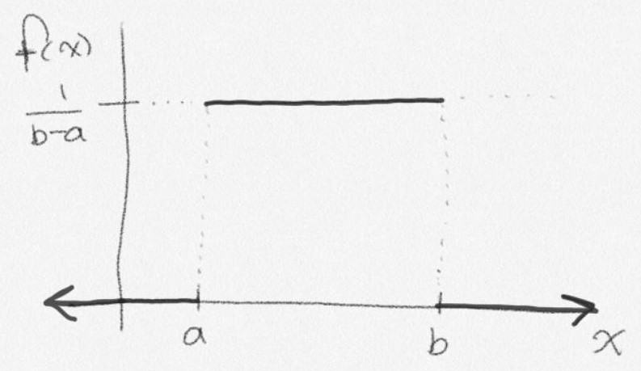

### cdf

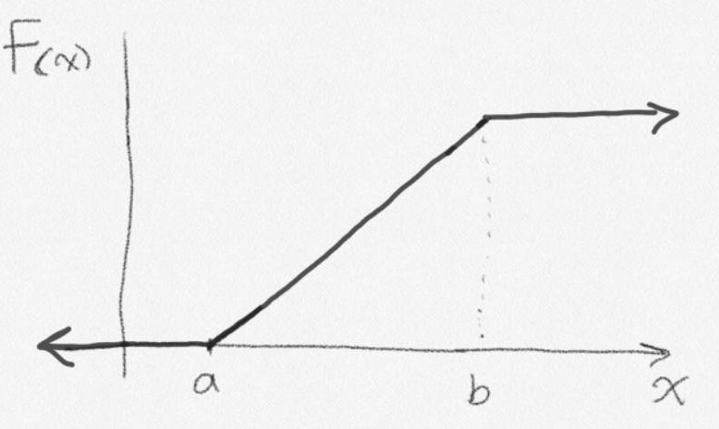

### Uniform Probability

For any interval, \( L_c \), of length \( c \) that is closed within \( (a,b) \),

\[ P(x \in L_c) = \frac{c}{b-a} \]

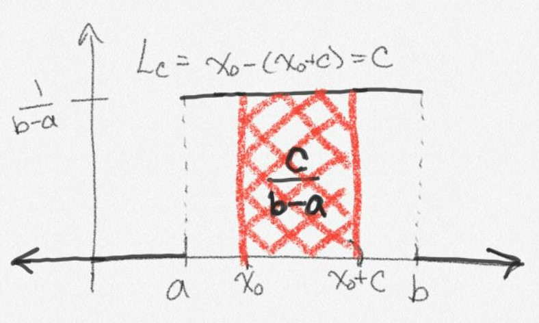

That is, when both \( x_0 \) and \( x_0 + c \) are elements of \( (a,b) \),

\[ P(x \in L_c) = \int\limits_{x_0}^{x_0+c}\frac{1}{b-a} dx = \frac{x_0 + c - x_0}{b-a} = \frac{c}{b-a} \]

### Uniform Example

My favorite statistics email arrives on Thursdays between \( 4 \) pm and \( 8 \) pm. Let \( \small X \) be the time the emails arrives on Thursday, assume \( \small X \sim Unif(4,8) \).

### What is the probability the emails arrives after \( 7:50 \) pm?

First consider the units of time in hours, then \( 7:50 pm \implies 7 + 50/60 hours = 47/6 \).

Need to find \( P(X > 47/6) \). What is the pdf?

\[ f(x) = \frac{1}{8-4}1_{(4,8)}(x) = \frac{1}{4}1_{(4,8)}(x) \]

Then

\[ P(X > 47/6) = \int\limits_{47/6}^{8}\frac{1}{4}dx = \frac{1}{4}(8 - 47/6) = \frac{1}{4}\cdot \frac{1}{6} = \frac{1}{24} \]

Using the CDF, we could have found

\[ P(X > 47/6) = 1 - P(X \leq 47/6) = 1 - F(47/6) = 1 - \frac{(47/6 - 4)}{4} = \frac{1}{24} \]